# Onderzoek Telefoongedrag

Michele Radaelli

26 februari 2016

# Onderzoek Telefoongedrag

### Inleiding

In dit onderzoek zal ik kijken naar mijn telefoongedrag gebaseerd op data van maart 2015 t/m jaunari 2016. Ik wil door dit onderzoek inzicht verkrijgen in mijn gedrag en mijzelf 3 aanbevelingen doen op basis van inzichten en conclusies die ik uit het onderzoek verkrijg.

### Data inlezen, opschonen en opknippen

De eerste stap is om data in te lezen. Zo ziet de data er dan uit:

```r
complete_data <- read.csv("./TelefoonGegevensMichele.csv", header=TRUE, stringsAsFactors = FALSE,
                           colClasses = "character", sep=";")
head(complete_data)
```

```
##     field1 field2   field3  field4   field5 field6 field7 field8
## 1 06/01/16  13:36 Internet gebruik  2880,99    kB)   \227   0,11
## 2 07/01/16  03:40 Internet gebruik  6015,31    kB)   \227   0,23
## 3 07/01/16  16:52 Internet gebruik  2389,53    kB)   \227   0,09
## 4 07/01/16  22:20 Internet gebruik 10027,05    kB)   \227   0,38
## 5 08/01/16  21:14 Internet gebruik 13150,58    kB)   \227   0,49
## 6 09/01/16  23:17 Internet gebruik 10038,89    kB)   \227   0,38
```

Vervolgens verschoon, filter en verrijk ik de data: - Ik cleans de data zodat verkeerde/onnodige symbolen goed komen te staan. - Ik verander de codering van de variabele zodat deze kunnen worden gebruikt in de analyse. - De kolommen die niet interessant zijn voor de analyse parkeer ik. - Ik cree??r nieuwe variabele die handig zijn voor het onderzoek (Maand, Weekdag, etc) - Ik verdeel de data in 2 frames op basis van een kenmerk uit field3 in Gesprek data en Internet data.

Zo ziet de schone en gefilterde data eruit:

```r
library(lubridate)
names(complete_data) <- c("Datum", "Tijd", "Type", "field4", "field5", "field6", "field7", "Prijs")
complete_data$Prijs <- as.numeric(gsub(",", ".", complete_data$Prijs))
complete_data$Maand <- factor(months(as.Date(complete_data$Datum, format = "%d/%m/%y")), ordered = TRUE,
                          levels = c("March", "April", "May", "June", "July", "August",
                                     "September", "October", "November", "December", "January"))
complete_data_split <- split(complete_data, complete_data$Type)

Gesprekken <- complete_data_split$Gesprek[, c(1,2,5,6,8)]
colnames(Gesprekken) <- c("Datum", "Tijd", "Telnummer", "Gespreksduur", "Prijs")
Gesprekken$Prijs <- gsub(",", ".", Gesprekken$Prijs)
Gesprekken$Uur <- factor(substr(Gesprekken$Tijd, 1, 2), ordered = TRUE,
                          levels = c("00", "01","02","03", "04", "05","06", "07", "08", "09", "10",
                                     "11","12","13","14","15","16","17","18","19","20","21", "22", "23"))
Gesprekken$Gespreksduur <- gsub(",", ".", Gesprekken$Gespreksduur)
Gesprekken$Gespreksduur <-  round(as.numeric(Gesprekken$Gespreksduur) * 86400)
Gesprekken$Weekdag <- factor(weekdays(as.Date(Gesprekken$Datum)), ordered = TRUE,
                             levels = c("Monday", "Tuesday", "Wednesday",
                                        "Thursday", "Friday", "Saturday", "Sunday"))
Gesprekken$Maand <- factor(months(as.Date(Gesprekken$Datum)), ordered = TRUE,
                           levels = c("March", "April", "May", "June", "July", "August",
                                      "September", "October", "November", "December", "January"))

Internet <- complete_data_split$Internet[, c(1,2,5,6,8)]
colnames(Internet) <- c("Datum", "Tijd", "Verbruik", "Eenheid", "Prijs")
Internet$Uur <- factor(substr(Internet$Tijd, 1, 2), ordered = TRUE,
                          levels = c("00", "01","02","03","04","05","06","07", "08", "09", "10",
                                     "11","12","13","14","15","16","17","18","19","20","21", "22", "23"))
Internet$Eenheid <- gsub(")", "", Internet$Eenheid)
Internet$Verbruik <- gsub("\\(", "", Internet$Verbruik)
Internet$Verbruik <- gsub(",", ".", Internet$Verbruik)
Internet$Verbruik <- as.numeric(Internet$Verbruik) / 1024
Internet$Weekdag <- factor(weekdays(as.Date(Internet$Datum)), ordered = TRUE,
                           levels = c("Monday", "Tuesday", "Wednesday",
                                      "Thursday", "Friday", "Saturday", "Sunday"))
Internet$Maand <- factor(months(as.Date(Internet$Datum)), ordered = TRUE,
                           levels = c("March", "April", "May", "June", "July", "August",
                                      "September", "October", "November", "December", "January"))

head(complete_data[, c(1,2,8,9)])
```

```
##      Datum  Tijd Prijs   Maand
## 1 06/01/16 13:36  0.11 January
## 2 07/01/16 03:40  0.23 January
## 3 07/01/16 16:52  0.09 January
## 4 07/01/16 22:20  0.38 January
## 5 08/01/16 21:14  0.49 January
## 6 09/01/16 23:17  0.38 January
```

```r
head(Gesprekken)
```

```
##         Datum  Tijd Telnummer Gespreksduur Prijs Uur   Weekdag   Maand
## 1747 06/01/16 11:48 631562787          131  0.11  11    Monday January
## 1748 06/01/16 13:35 629525639            5  0.04  13    Monday January
## 1749 11/01/16 12:59 615442940           63  0.08  12    Sunday January
## 1750 11/01/16 16:35 654705139            5  0.04  16    Sunday January
## 1751 12/01/16 17:00 683690918          201  0.15  17    Monday January
## 1752 13/01/16 15:14 615422080          129  0.11  15 Wednesday January
```

```r
head(Internet)
```

```
##      Datum  Tijd  Verbruik Eenheid Prijs Uur   Weekdag   Maand
## 1 06/01/16 13:36  2.813467      kB  0.11  13    Monday January
## 2 07/01/16 03:40  5.874326      kB  0.23  03   Tuesday January
## 3 07/01/16 16:52  2.333525      kB  0.09  16   Tuesday January
## 4 07/01/16 22:20  9.792041      kB  0.38  22   Tuesday January
## 5 08/01/16 21:14 12.842363      kB  0.49  21 Wednesday January
## 6 09/01/16 23:17  9.803604      kB  0.38  23    Friday January
```

### Analyse per weekdag (Gesprek vs. Internet)

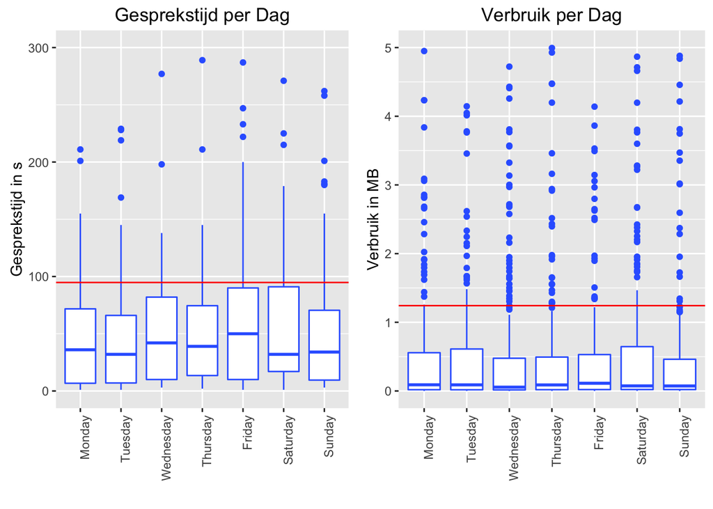

```r
library(ggplot2)
Gesprekken_gem_dag <- aggregate(as.numeric(Gesprekken$Gespreksduur), by=list(Gesprekken$Weekdag), FUN="mean")
colnames(Gesprekken_gem_dag) <- c("Weekdag", "GemDag")

plot1 <-
  ggplot(Gesprekken, aes(Weekdag, Gespreksduur)) +  geom_boxplot(colour = I("#3366FF")) + ylim(c(0, 300)) +
  geom_hline(yintercept = mean(as.numeric(Gesprekken$Gespreksduur)), colour = "red") +
  ylab("Gesprekstijd in s") + xlab("") +
  ggtitle("Gesprekstijd per Dag") +
  theme(axis.text.x = element_text(angle = 90, hjust = 1))

Internet_gem_dag <- aggregate(as.numeric(Internet$Verbruik), by=list(Internet$Weekdag), FUN="mean")
colnames(Internet_gem_dag) <- c("Weekdag", "GemDag")

plot2 <-
  ggplot(Internet, aes(Weekdag, Verbruik)) +  geom_boxplot(colour = I("#3366FF")) + ylim(c(0, 5)) +
  geom_hline(yintercept = mean(as.numeric(Internet$Verbruik)), colour = "red") +
  ylab("Verbruik in MB") + xlab("") +
  ggtitle("Verbruik per Dag") +
  theme(axis.text.x = element_text(angle = 90, hjust = 1))

library(Rmisc)
multiplot(plot1, plot2, cols=2)
```

```r
#aggiungere numero di chiamate
```

Uit deze analyse blijkt dat de meeste (iedere dag meer dan 75%) gesprek/interenet momenten ondergemiddeld zijn in tijd/verbruik. Daarnaast is geen duidelijk patroon te zien gedurende de week.

### Analyse per maand (Gesprek vs. Internet vs. Kosten)

In deze analyse kijke we naar het verloop van het telefoon gebruik over de maanden heen. In het blauw zien we een simpele lineaire regressie. Deze geeft een eerste schatting van het verloop in de tijd.

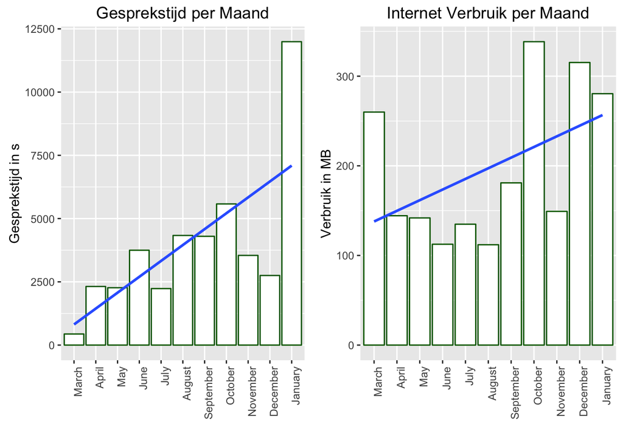

```r
Gesprekken_maand <- aggregate(as.numeric(Gesprekken$Gespreksduur), by=list(Gesprekken$Maand), FUN="sum")
colnames(Gesprekken_maand) <- c("Maand", "GesprMaand")

plot3 <-
  ggplot(Gesprekken_maand, aes(x = Maand, y = GesprMaand)) +
  geom_bar(stat = "identity", fill="white", colour="darkgreen") + ylab("Gesprekstijd in s") + xlab("") +
  stat_smooth(method="lm", aes(x = 1:11), se=FALSE) +
  ggtitle("Gesprekstijd per Maand") +
  theme(axis.text.x = element_text(angle = 90, hjust = 1)) + scale_fill_brewer()

Internet_maand <- aggregate(as.numeric(Internet$Verbruik), by=list(Internet$Maand), FUN="sum")
colnames(Internet_maand) <- c("Maand", "VerbrMaand")

plot4 <-
  ggplot(Internet_maand, aes(x = Maand, y = VerbrMaand)) +
  geom_bar(stat = "identity", fill="white", colour="darkgreen") + ylab("Verbruik in MB") + xlab("") +
  stat_smooth(method="lm", aes(x = 1:11), se=FALSE) +
  ggtitle("Internet Verbruik per Maand") +
  theme(axis.text.x = element_text(angle = 90, hjust = 1))

multiplot(plot3, plot4, cols=2)
```

We zien dat zowel de gesprekstijd als het internetverbruik sterk toeneemt in de tijd. Daarnaast zien we dat de afgelopen maand twee keer zoveel gebeld is als de ????n na hoogste peik. Dit zien we niet terug in het internetverbruik.

Ik ga nu onderzoeken is wat de relatie tussen gesprekstijd en internetverbruik is door de maanden heen. Daarnaast kijk is hoe het verloop van de kosten is. In de grafiek zien we in het rood de hoogte van de bundel. Die is altijd 7,50 euro geweest en tot nu toe nooit gewijzigd. Hier ook zien we een lineaire regressie benadering van de kosten in de tijd.

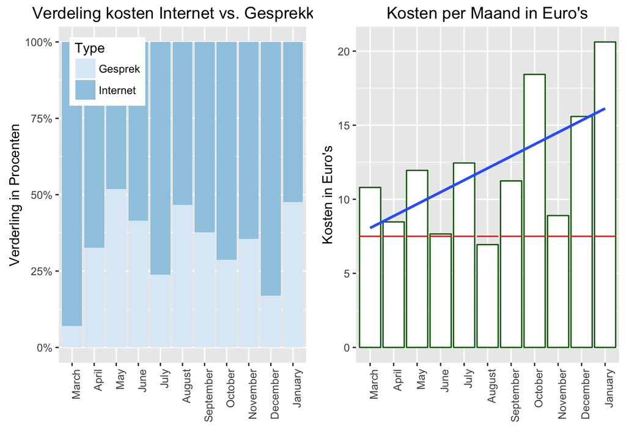

```r
Prijs_per_maand <- aggregate(as.numeric(complete_data$Prijs), by = list(complete_data$Maand), FUN = "sum")
names(Prijs_per_maand) <- c("Maand", "Kosten")
Prijs_per_maand_type <- aggregate(as.numeric(complete_data$Prijs), by = list(complete_data$Maand, complete_data$Type), FUN = "sum")
names(Prijs_per_maand_type) <- c("Maand", "Type", "Kosten")

Prijs_per_maand$bundle <- c(rep(7.50 , 11))

plot5 <-
  ggplot(Prijs_per_maand, aes(x = Maand, y = Kosten)) +
  geom_bar(stat = "identity", fill="white", colour="darkgreen") + ylab("Kosten in Euro's") +
  stat_smooth(method="lm", aes(x = 1:11), se=FALSE) +
  geom_errorbar(aes(y = bundle, ymin = bundle, ymax = bundle), colour = "red") +
  xlab("") + ggtitle("Kosten per Maand in Euro's") +
  theme(axis.text.x = element_text(angle = 90, hjust = 1))

plot6 <-
  ggplot(Prijs_per_maand_type, aes(x = Maand, y = Kosten, fill=Type)) +
  geom_bar(position="fill", stat = "identity") + ylab("Verderling in Procenten") +
  xlab("") + ggtitle("Verdeling kosten Internet vs. Gesprekken") +
  theme(axis.text.x = element_text(angle = 90, hjust = 1)) +
  scale_y_continuous(labels =scales::percent) +
  theme(legend.justification=c(0,1), legend.position=c(0,1)) +
  scale_fill_brewer()


multiplot(plot6, plot5, cols=2)
```

```r
#lm  in grafico 6
#media sopra il bundel in grafico 5
#grafico con settimane cumulative al mese e bundel. Per vedere in che settimana si supera
```

### Analyse per uur (Gesprek vs. Internet)

Ik aggregeer nu de verbruiksdata per uur. Ik kijk over alle dagen heen wat het verbruik ieder uur is geweest. In de grafiek is ook een LOESS regressie te zien. Dit is een gewogen middenmaat waarbij de punten dichter bij deze maat een groter gewicht hebben ten opzichte van de punten die hier verder vanaf liggen. Hoe smaller de smoothing, hoe representatiever de middenmaat is. Deze middenmaat wil alleen een impressie geven over het verloop van het gebruik gedurende de dag.

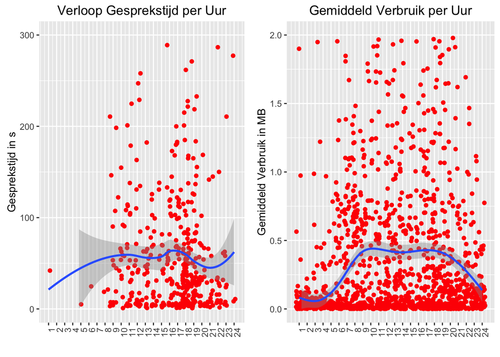

```r
Gesprekken_gem_uur <- aggregate(as.numeric(Gesprekken$Gespreksduur), by=list(Gesprekken$Uur), FUN="mean")
colnames(Gesprekken_gem_uur) <- c("Tijd", "GemUur")

plot7 <-
  ggplot(Gesprekken, aes(as.numeric(Uur), Gespreksduur)) + geom_jitter(color="red") +
  geom_smooth() + ylim(c(0, 300)) +
  ylab("Gesprekstijd in s") + xlab("") +
  ggtitle("Verloop Gesprekstijd per Uur") +
  theme(axis.text.x = element_text(angle = 90, hjust = 1)) +
  scale_x_continuous(breaks=seq(1, 24, 1))

Internet_gem_uur <- aggregate(as.numeric(Internet$Verbruik), by=list(Internet$Uur), FUN="mean")
colnames(Internet_gem_uur) <- c("Tijd", "GemUur")

plot8 <-
  ggplot(Internet, aes(as.numeric(Uur), Verbruik)) + geom_jitter(color="red") +
  geom_smooth() + ylim(c(0, 2)) +
  ylab("Gemiddeld Verbruik in MB") + xlab("") +
  ggtitle("Gemiddeld Verbruik per Uur") +
  theme(axis.text.x = element_text(angle = 90, hjust = 1)) +
  scale_x_continuous(breaks=seq(1, 24, 1))

multiplot(plot7, plot8, cols=2)
```

We zien dat er ’s nachts op een paar uitzonderingen na niet gebeld is, terwijl er vaak gebruik is gemaakt van internet. Dit vebruik bevat echter alleen hele lage verbruiks momenten. Dit zou verklaard kunnen worden door notificaties of inkomende berichten die dan worden ontvangen zondar dat de gebruiker actief gebruik maakt van de telefoon. Het internetverbruik blijkt van 8 tot 18 uur continu hoog te zijn. Terwijl deze, maar ook de gesprekstijd, in de avond vlink afneemt. De verklaring voor de dip in verbruik is dat ik ’s avonds Wi-Fi gebruik als ik thuis ben. De dip in gesprestijd is te verklaren doordat we kijken naar een telefoon van de zaak, deze wordt dus voornamelijk op kantoor gebruikt.

### Analyse meest gebelde nummers

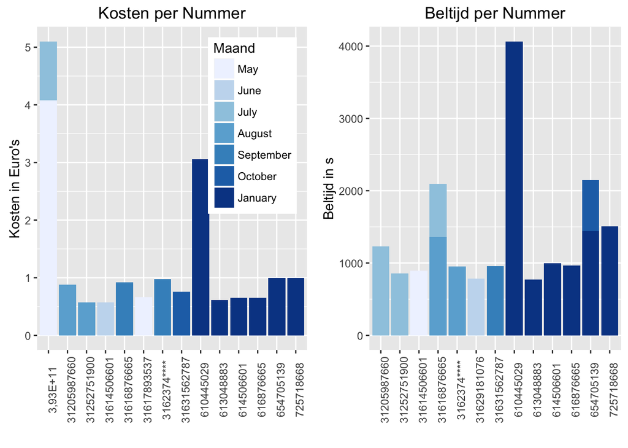

```r
library(plyr)
Tijd_per_nummer <- aggregate(Gesprekken$Gespreksduur, by = list(Gesprekken$Telnummer, Gesprekken$Maand), 'sum')

Prijs_per_nummer <- aggregate(as.numeric(Gesprekken$Prijs), by = list(Gesprekken$Telnummer, Gesprekken$Maand), 'sum')

colnames(Tijd_per_nummer) <- c("Nummer", "Maand", "SomTijd")
colnames(Prijs_per_nummer) <- c("Nummer", "Maand", "SomPrijs")

Tijd_per_nummer_top <- arrange(Tijd_per_nummer, desc(SomTijd))[1:15,]
Prijs_per_nummer_top <- arrange(Prijs_per_nummer, desc(SomPrijs))[1:15,]


plot9 <-
  ggplot(Tijd_per_nummer_top, aes(x = Nummer, y = SomTijd, fill= Maand)) +
  geom_bar(stat = "identity") + ylab("Beltijd in s") + xlab("") +
  ggtitle("Beltijd per Nummer") +
  theme(axis.text.x = element_text(angle = 90)) +
  theme(legend.position='none') +
  scale_fill_brewer()

plot10 <-
  ggplot(Prijs_per_nummer_top, aes(x = Nummer, y = SomPrijs, fill= Maand)) +
  geom_bar(stat = "identity") + ylab("Kosten in Euro's") + xlab("") +
  ggtitle("Kosten per Nummer") +
  theme(axis.text.x = element_text(angle = 90)) +
  theme(legend.justification=c(1,1), legend.position=c(1,1)) +
  scale_fill_brewer()


multiplot(plot10, plot9, cols=2)
```

```r
#correggere numeri di telefono
```

### Analyse voorspelling komende maanden (Gesprek vs. Internet)

Ik ga nu de ksoten analyseren in de afelopen maanden om een schatting te kunnen doen van de kosten in de komende maande. Ik cree??r een tijdsreeks met de data. Deze tijdsreeks heeft 11 observaties. Ik vergelijk 2 forecast modellen. De eerste 7 observaties vormen mijn train set. De laatste 4 vormen mijn test set. De fout van de forecast tenopzichte van de test set is hier te zien:

```r
library(forecast)
Time_series <- ts(Prijs_per_maand$Kosten)
length_ts <- length(Time_series)

Time_series_train1 <- Time_series[1:(length_ts-4)]
Time_series_test1 <- Time_series[(length_ts-3):length_ts]
model_autoarima1 <- auto.arima(Time_series_train1)
model_ets1 <- ets(Time_series_train1)
forecast_autoarima1 <- forecast(model_autoarima1, 4)
forecast_ets1 <- forecast(model_ets1, 4)
error_autoarima1 <- sqrt(sum((forecast_autoarima1$mean-Time_series_test1)*(forecast_autoarima1$mean-Time_series_test1)))
error_ets1 <- sqrt(sum((forecast_ets1$mean-Time_series_test1)*(forecast_ets1$mean-Time_series_test1)))

error_autoarima1
```

```
## [1] 15.81032
```

```r
error_ets1
```

```
## [1] 14.81954
```

De fout is te groot om een voorspelling te kunnen doen voor 4 maanden. Ik probeer een grotere train set te gebruiken en een kleienere test set. Op deze manier kan ik inschatten hoe betrouwbaar de voorspelling voor de eerstvolgende maand kan zijn. Dit zijn de fouten voor de twee modellen:

```r
Time_series_train2 <- Time_series[1:(length_ts-1)]
Time_series_test2 <- Time_series[length_ts]
model_autoarima2 <- auto.arima(Time_series_train2)
model_ets2 <- ets(Time_series_train2)
forecast_autoarima2 <- forecast(model_autoarima2, 1)
forecast_ets2 <- forecast(model_ets2, 1)
error_autoarima2 <- sqrt(sum((forecast_autoarima2$mean-Time_series_test2)*(forecast_autoarima2$mean-Time_series_test2)))
error_ets2 <- sqrt(sum((forecast_ets2$mean-Time_series_test2)*(forecast_ets2$mean-Time_series_test2)))

error_autoarima2
```

```
## [1] 9.377
```

```r
error_ets2
```

```
## [1] 9.377216
```

We zien dat de fout bijna hetzelfde is voor de twee modellen maar net iets kleiner voor de auto_arima model. We kiezen dit model dus om de kosten te voorstellen voor de komdende maand. Dit is het resultaat:

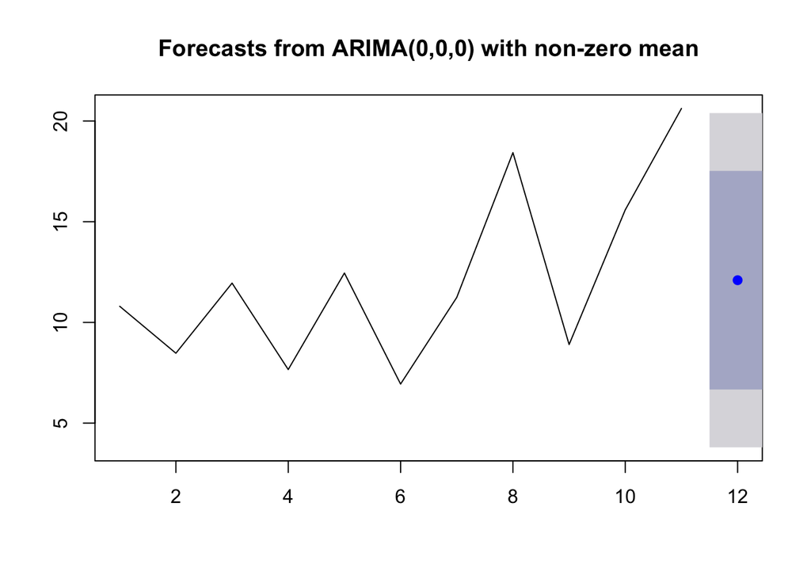

```r
model_autoarima <- auto.arima(Time_series)
forecast_autoarima <- forecast(model_autoarima, 1)
plot(forecast_autoarima)
```

```r
#pd <- funggcast(Time_series, forecast_autoarima)
#p <- ggplot(forecast_autoarima, aes(mean)) + geom_line()
```